# Advanced Data Modelling with R: Predicting Wine Quality

Rachel Andine

2025-04-21

Step 1.1 Import Libraries

```r
library(tidyverse)
library(janitor)       # For cleaning column names
library(caret)         # For modeling and training control
library(data.table)    # Efficient data handling
```

```r
library(ggplot2)       # Visualization
library(dplyr)
library(gt)            # Table formatting
library(scales)
library(ggcorrplot)    # For correlation matrix heatmaps
library(rpart)         # Decision trees
library(rpart.plot)    # Visualize decision trees
library(randomForest)  # Random forest modeling
library(yardstick)     # For model evaluation
library(nnet)          # Multinomial logistic regression
```

All libraries imported successfully

Step 2 | Importing and inspecting data

```r
wine <- read_delim("Wine Quality (Red Wine).csv")
head(wine)
```

```
## # A tibble: 6 × 12
##   `fixed acidity` `volatile acidity` `citric acid` `residual sugar` chlorides
##             <dbl>              <dbl>         <dbl>            <dbl>     <dbl>
## 1             7.4               0.7           0                 1.9     0.076
## 2             7.8               0.88          0                 2.6     0.098
## 3             7.8               0.76          0.04              2.3     0.092
## 4            11.2               0.28          0.56              1.9     0.075
## 5             7.4               0.7           0                 1.9     0.076
## 6             7.4               0.66          0                 1.8     0.075
## # ℹ 7 more variables: `free sulfur dioxide` <dbl>,
## #   `total sulfur dioxide` <dbl>, density <dbl>, pH <dbl>, sulphates <dbl>,
## #   alcohol <dbl>, quality <dbl>
```

```r
skimr::skim(wine)
```

Data summary

| Name | wine |
| --- | --- |
| Number of rows | 1599 |
| Number of columns | 12 |
| _______________________ |  |
| Column type frequency: |  |
| numeric | 12 |
| ________________________ |  |
| Group variables | None |

**Variable type: numeric**

| skim_variable | n_missing | complete_rate | mean | sd | p0 | p25 | p50 | p75 | p100 | hist |
| --- | --- | --- | --- | --- | --- | --- | --- | --- | --- | --- |
| fixed acidity | 0 | 1 | 8.32 | 1.74 | 4.60 | 7.10 | 7.90 | 9.20 | 15.90 | ▂▇▂▁▁ |
| volatile acidity | 0 | 1 | 0.53 | 0.18 | 0.12 | 0.39 | 0.52 | 0.64 | 1.58 | ▅▇▂▁▁ |
| citric acid | 0 | 1 | 0.27 | 0.19 | 0.00 | 0.09 | 0.26 | 0.42 | 1.00 | ▇▆▅▁▁ |
| residual sugar | 0 | 1 | 2.54 | 1.41 | 0.90 | 1.90 | 2.20 | 2.60 | 15.50 | ▇▁▁▁▁ |
| chlorides | 0 | 1 | 0.09 | 0.05 | 0.01 | 0.07 | 0.08 | 0.09 | 0.61 | ▇▁▁▁▁ |
| free sulfur dioxide | 0 | 1 | 15.87 | 10.46 | 1.00 | 7.00 | 14.00 | 21.00 | 72.00 | ▇▅▁▁▁ |
| total sulfur dioxide | 0 | 1 | 46.47 | 32.90 | 6.00 | 22.00 | 38.00 | 62.00 | 289.00 | ▇▂▁▁▁ |
| density | 0 | 1 | 1.00 | 0.00 | 0.99 | 1.00 | 1.00 | 1.00 | 1.00 | ▁▃▇▂▁ |
| pH | 0 | 1 | 3.31 | 0.15 | 2.74 | 3.21 | 3.31 | 3.40 | 4.01 | ▁▅▇▂▁ |
| sulphates | 0 | 1 | 0.66 | 0.17 | 0.33 | 0.55 | 0.62 | 0.73 | 2.00 | ▇▅▁▁▁ |
| alcohol | 0 | 1 | 10.42 | 1.07 | 8.40 | 9.50 | 10.20 | 11.10 | 14.90 | ▇▇▃▁▁ |
| quality | 0 | 1 | 5.64 | 0.81 | 3.00 | 5.00 | 6.00 | 6.00 | 8.00 | ▁▇▇▂▁ |

```r
glimpse(wine)
```

```
## Rows: 1,599
## Columns: 12
## $ `fixed acidity`        <dbl> 7.4, 7.8, 7.8, 11.2, 7.4, 7.4, 7.9, 7.3, 7.8, 7…
## $ `volatile acidity`     <dbl> 0.700, 0.880, 0.760, 0.280, 0.700, 0.660, 0.600…
## $ `citric acid`          <dbl> 0.00, 0.00, 0.04, 0.56, 0.00, 0.00, 0.06, 0.00,…
## $ `residual sugar`       <dbl> 1.9, 2.6, 2.3, 1.9, 1.9, 1.8, 1.6, 1.2, 2.0, 6.…
## $ chlorides              <dbl> 0.076, 0.098, 0.092, 0.075, 0.076, 0.075, 0.069…
## $ `free sulfur dioxide`  <dbl> 11, 25, 15, 17, 11, 13, 15, 15, 9, 17, 15, 17, …
## $ `total sulfur dioxide` <dbl> 34, 67, 54, 60, 34, 40, 59, 21, 18, 102, 65, 10…
## $ density                <dbl> 0.9978, 0.9968, 0.9970, 0.9980, 0.9978, 0.9978,…
## $ pH                     <dbl> 3.51, 3.20, 3.26, 3.16, 3.51, 3.51, 3.30, 3.39,…
## $ sulphates              <dbl> 0.56, 0.68, 0.65, 0.58, 0.56, 0.56, 0.46, 0.47,…
## $ alcohol                <dbl> 9.4, 9.8, 9.8, 9.8, 9.4, 9.4, 9.4, 10.0, 9.5, 1…
## $ quality                <dbl> 5, 5, 5, 6, 5, 5, 5, 7, 7, 5, 5, 5, 5, 5, 5, 5,…
```

```r
str(wine)
```

```
## spc_tbl_ [1,599 × 12] (S3: spec_tbl_df/tbl_df/tbl/data.frame)
##  $ fixed acidity       : num [1:1599] 7.4 7.8 7.8 11.2 7.4 7.4 7.9 7.3 7.8 7.5 ...
##  $ volatile acidity    : num [1:1599] 0.7 0.88 0.76 0.28 0.7 0.66 0.6 0.65 0.58 0.5 ...
##  $ citric acid         : num [1:1599] 0 0 0.04 0.56 0 0 0.06 0 0.02 0.36 ...
##  $ residual sugar      : num [1:1599] 1.9 2.6 2.3 1.9 1.9 1.8 1.6 1.2 2 6.1 ...
##  $ chlorides           : num [1:1599] 0.076 0.098 0.092 0.075 0.076 0.075 0.069 0.065 0.073 0.071 ...
##  $ free sulfur dioxide : num [1:1599] 11 25 15 17 11 13 15 15 9 17 ...
##  $ total sulfur dioxide: num [1:1599] 34 67 54 60 34 40 59 21 18 102 ...
##  $ density             : num [1:1599] 0.998 0.997 0.997 0.998 0.998 ...
##  $ pH                  : num [1:1599] 3.51 3.2 3.26 3.16 3.51 3.51 3.3 3.39 3.36 3.35 ...
##  $ sulphates           : num [1:1599] 0.56 0.68 0.65 0.58 0.56 0.56 0.46 0.47 0.57 0.8 ...
##  $ alcohol             : num [1:1599] 9.4 9.8 9.8 9.8 9.4 9.4 9.4 10 9.5 10.5 ...
##  $ quality             : num [1:1599] 5 5 5 6 5 5 5 7 7 5 ...
##  - attr(*, "spec")=
##   .. cols(
##   ..   `fixed acidity` = col_double(),
##   ..   `volatile acidity` = col_double(),
##   ..   `citric acid` = col_double(),
##   ..   `residual sugar` = col_double(),
##   ..   chlorides = col_double(),
##   ..   `free sulfur dioxide` = col_double(),
##   ..   `total sulfur dioxide` = col_double(),
##   ..   density = col_double(),
##   ..   pH = col_double(),
##   ..   sulphates = col_double(),
##   ..   alcohol = col_double(),
##   ..   quality = col_double()
##   .. )
##  - attr(*, "problems")=<externalptr>
```

```r
summary(wine)
```

```
##  fixed acidity   volatile acidity  citric acid    residual sugar
##  Min.   : 4.60   Min.   :0.1200   Min.   :0.000   Min.   : 0.900
##  1st Qu.: 7.10   1st Qu.:0.3900   1st Qu.:0.090   1st Qu.: 1.900
##  Median : 7.90   Median :0.5200   Median :0.260   Median : 2.200
##  Mean   : 8.32   Mean   :0.5278   Mean   :0.271   Mean   : 2.539
##  3rd Qu.: 9.20   3rd Qu.:0.6400   3rd Qu.:0.420   3rd Qu.: 2.600
##  Max.   :15.90   Max.   :1.5800   Max.   :1.000   Max.   :15.500
##    chlorides       free sulfur dioxide total sulfur dioxide    density
##  Min.   :0.01200   Min.   : 1.00       Min.   :  6.00       Min.   :0.9901
##  1st Qu.:0.07000   1st Qu.: 7.00       1st Qu.: 22.00       1st Qu.:0.9956
##  Median :0.07900   Median :14.00       Median : 38.00       Median :0.9968
##  Mean   :0.08747   Mean   :15.87       Mean   : 46.47       Mean   :0.9967
##  3rd Qu.:0.09000   3rd Qu.:21.00       3rd Qu.: 62.00       3rd Qu.:0.9978
##  Max.   :0.61100   Max.   :72.00       Max.   :289.00       Max.   :1.0037
##        pH          sulphates         alcohol         quality
##  Min.   :2.740   Min.   :0.3300   Min.   : 8.40   Min.   :3.000
##  1st Qu.:3.210   1st Qu.:0.5500   1st Qu.: 9.50   1st Qu.:5.000
##  Median :3.310   Median :0.6200   Median :10.20   Median :6.000
##  Mean   :3.311   Mean   :0.6581   Mean   :10.42   Mean   :5.636
##  3rd Qu.:3.400   3rd Qu.:0.7300   3rd Qu.:11.10   3rd Qu.:6.000
##  Max.   :4.010   Max.   :2.0000   Max.   :14.90   Max.   :8.000
```

Step 3 | Check for missing values and Duplicates

```r
wine <- wine %>% clean_names()

# Check for missing values
missing_total <- sum(is.na(wine))
if (missing_total == 0) {
  print("✅ No missing values in the dataset.")
} else {
  print(paste("⚠️", missing_total, "missing values found."))
}
```

```
## [1] "✅ No missing values in the dataset."
```

```r
# Check for duplicate rows
duplicate_total <- sum(duplicated(wine))
if (duplicate_total == 0) {
  print("✅ No duplicated rows found.")
} else {
  print(paste("⚠️", duplicate_total, "duplicated rows detected."))
}
```

```
## [1] "⚠️ 240 duplicated rows detected."
```

```r
# This removes duplicated rows across all columns
wine <- wine %>% distinct()

#to check if duplicate was removed
skimr::skim(wine)
```

Data summary

| Name | wine |
| --- | --- |
| Number of rows | 1359 |
| Number of columns | 12 |
| _______________________ |  |
| Column type frequency: |  |
| numeric | 12 |
| ________________________ |  |
| Group variables | None |

**Variable type: numeric**

| skim_variable | n_missing | complete_rate | mean | sd | p0 | p25 | p50 | p75 | p100 | hist |
| --- | --- | --- | --- | --- | --- | --- | --- | --- | --- | --- |
| fixed_acidity | 0 | 1 | 8.31 | 1.74 | 4.60 | 7.10 | 7.90 | 9.20 | 15.90 | ▂▇▂▁▁ |
| volatile_acidity | 0 | 1 | 0.53 | 0.18 | 0.12 | 0.39 | 0.52 | 0.64 | 1.58 | ▅▇▂▁▁ |
| citric_acid | 0 | 1 | 0.27 | 0.20 | 0.00 | 0.09 | 0.26 | 0.43 | 1.00 | ▇▆▅▁▁ |
| residual_sugar | 0 | 1 | 2.52 | 1.35 | 0.90 | 1.90 | 2.20 | 2.60 | 15.50 | ▇▁▁▁▁ |
| chlorides | 0 | 1 | 0.09 | 0.05 | 0.01 | 0.07 | 0.08 | 0.09 | 0.61 | ▇▁▁▁▁ |
| free_sulfur_dioxide | 0 | 1 | 15.89 | 10.45 | 1.00 | 7.00 | 14.00 | 21.00 | 72.00 | ▇▅▁▁▁ |
| total_sulfur_dioxide | 0 | 1 | 46.83 | 33.41 | 6.00 | 22.00 | 38.00 | 63.00 | 289.00 | ▇▂▁▁▁ |
| density | 0 | 1 | 1.00 | 0.00 | 0.99 | 1.00 | 1.00 | 1.00 | 1.00 | ▁▃▇▂▁ |
| p_h | 0 | 1 | 3.31 | 0.16 | 2.74 | 3.21 | 3.31 | 3.40 | 4.01 | ▁▅▇▂▁ |
| sulphates | 0 | 1 | 0.66 | 0.17 | 0.33 | 0.55 | 0.62 | 0.73 | 2.00 | ▇▅▁▁▁ |
| alcohol | 0 | 1 | 10.43 | 1.08 | 8.40 | 9.50 | 10.20 | 11.10 | 14.90 | ▇▇▅▁▁ |
| quality | 0 | 1 | 5.62 | 0.82 | 3.00 | 5.00 | 6.00 | 6.00 | 8.00 | ▁▇▇▂▁ |

Summary statistic table

```r
eda_summary <- wine %>%
  select(where(is.numeric)) %>%
  summarise(across(everything(), list(
    mean = mean,
    sd = sd,
    min = min,
    median = median,
    max = max
  ), .names = "{.fn}_{.col}")) %>%
  pivot_longer(everything(), names_to = "stat_var", values_to = "value") %>%
  separate(stat_var, into = c("stat", "variable"), sep = "_", extra = "merge") %>%
  pivot_wider(names_from = stat, values_from = value)

# Display table with gradient
eda_summary %>%
  gt() %>%
  data_color(
    columns = c(mean, sd, min, median, max),
    colors = col_numeric("Blues", domain = NULL)
  )
```

| variable | mean | sd | min | median | max |
| --- | --- | --- | --- | --- | --- |
| fixed_acidity | 8.31059603 | 1.736989808 | 4.60000 | 7.9000 | 15.90000 |
| volatile_acidity | 0.52947756 | 0.183031318 | 0.12000 | 0.5200 | 1.58000 |
| citric_acid | 0.27233260 | 0.195536545 | 0.00000 | 0.2600 | 1.00000 |
| residual_sugar | 2.52339956 | 1.352313758 | 0.90000 | 2.2000 | 15.50000 |
| chlorides | 0.08812362 | 0.049376862 | 0.01200 | 0.0790 | 0.61100 |
| free_sulfur_dioxide | 15.89330390 | 10.447270259 | 1.00000 | 14.0000 | 72.00000 |
| total_sulfur_dioxide | 46.82597498 | 33.408945707 | 6.00000 | 38.0000 | 289.00000 |
| density | 0.99670895 | 0.001868917 | 0.99007 | 0.9967 | 1.00369 |
| p_h | 3.30978661 | 0.155036311 | 2.74000 | 3.3100 | 4.01000 |
| sulphates | 0.65870493 | 0.170666891 | 0.33000 | 0.6200 | 2.00000 |
| alcohol | 10.43231543 | 1.082065450 | 8.40000 | 10.2000 | 14.90000 |
| quality | 5.62325239 | 0.823578002 | 3.00000 | 6.0000 | 8.00000 |

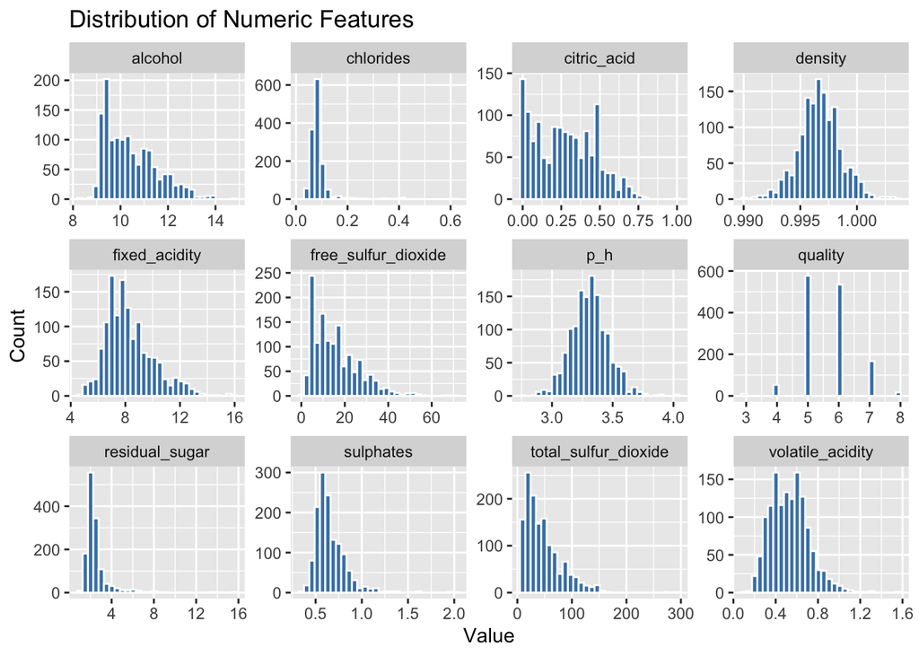

```r
# Plot histograms for all numeric variables
wine %>%
  select(where(is.numeric)) %>%
  pivot_longer(everything()) %>%
  ggplot(aes(x = value)) +
  geom_histogram(bins = 30, fill = "steelblue", color = "white") +
  facet_wrap(~name, scales = "free") +
  labs(title = "Distribution of Numeric Features", x = "Value", y = "Count")
```

Boxplots for outlier detection

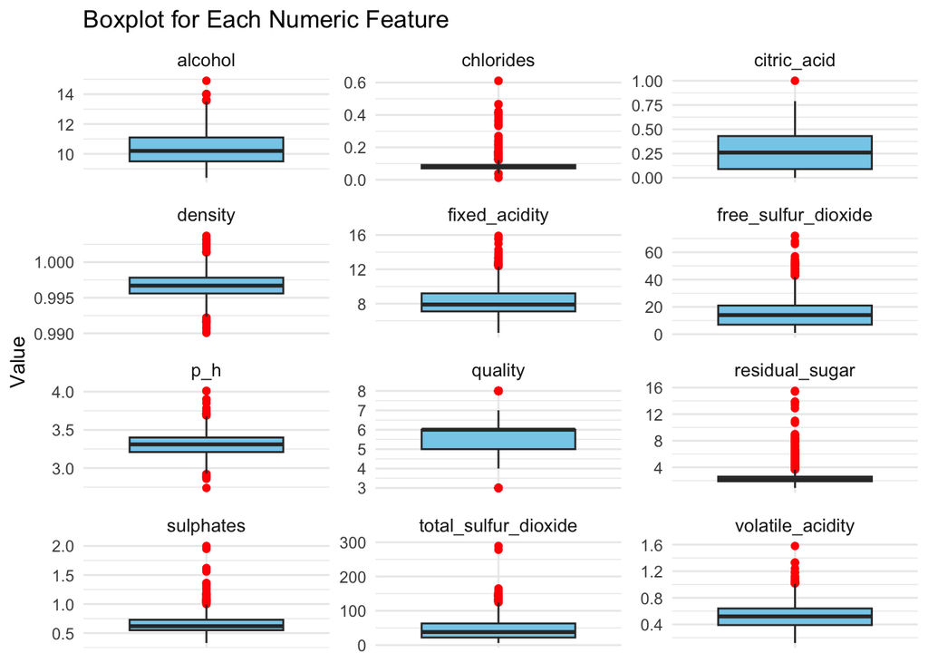

```r
wine %>%
  select(where(is.numeric)) %>%
  pivot_longer(cols = everything(), names_to = "variable", values_to = "value") %>%
  ggplot(aes(x = "", y = value)) +
  geom_boxplot(fill = "skyblue", outlier.color = "red") +
  facet_wrap(~variable, scales = "free", ncol = 3) +
  labs(title = "Boxplot for Each Numeric Feature",
       x = NULL, y = "Value") +
  theme_minimal() +
  theme(axis.text.x = element_blank(),
        strip.text = element_text(size = 10))
```

scatter plot

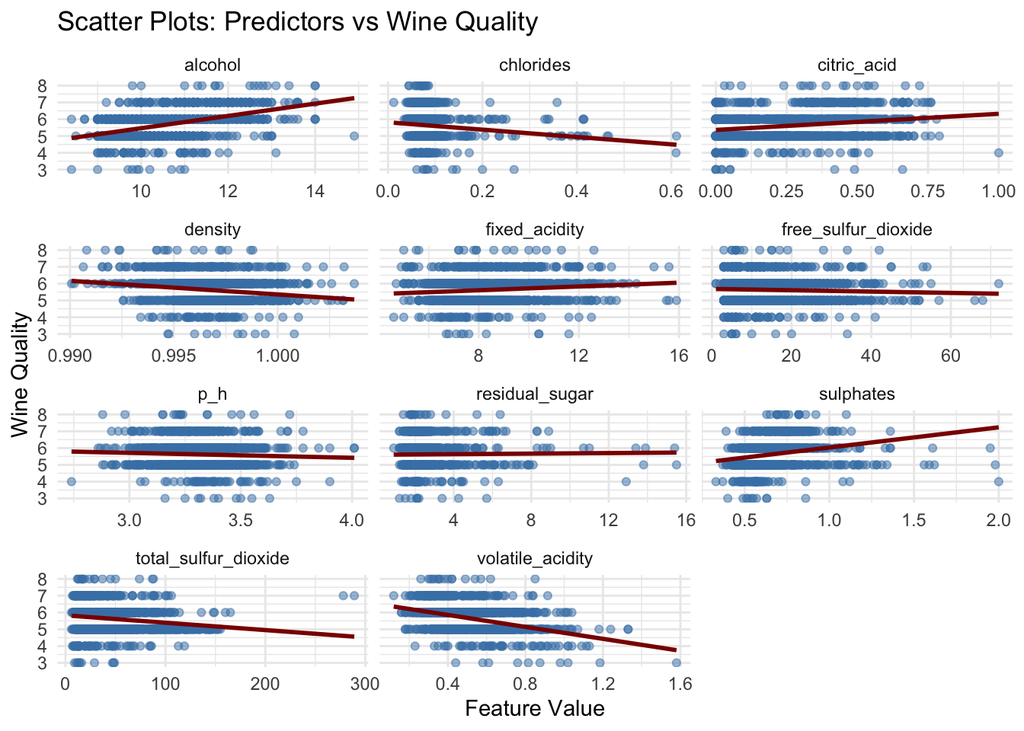

```r
library(tidyverse)

# Create scatter plots of each numeric variable against quality
wine %>%
  select(where(is.numeric)) %>%
  pivot_longer(cols = -quality, names_to = "variable", values_to = "value") %>%
  ggplot(aes(x = value, y = quality)) +
  geom_point(alpha = 0.5, color = "steelblue") +
  geom_smooth(method = "lm", se = FALSE, color = "darkred") +
  facet_wrap(~variable, scales = "free_x", ncol = 3) +
  labs(title = "Scatter Plots: Predictors vs Wine Quality",
       x = "Feature Value",
       y = "Wine Quality") +
  theme_minimal()
```

Correlation Matrix and Heatmap

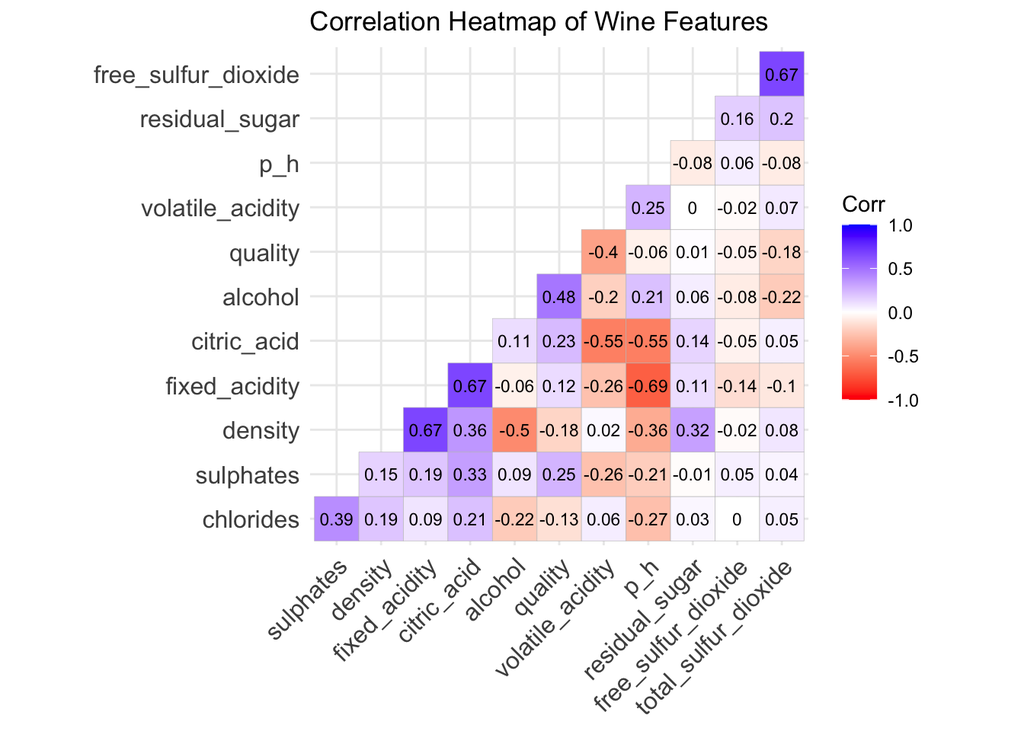

```r
# Compute correlation matrix
cor_matrix <- cor(wine %>% select(where(is.numeric)))

# Plot heatmap using ggcorrplot
ggcorrplot(
  cor_matrix,
  hc.order = TRUE,              # Hierarchical clustering for better layout
  type = "lower",               # Show only lower triangle
  lab = TRUE,                   # Add correlation coefficients
  lab_size = 3,
  colors = c("red", "white", "blue"),  # Gradient from negative to positive
  title = "Correlation Heatmap of Wine Features",
  ggtheme = theme_minimal()
)
```

categorise the quality

```r
# Create a quality category column
wine$quality_cat <- cut(
  wine$quality,
  breaks = c(0, 5, 6, 10),
  labels = c("Low", "Medium", "High"),
  include.lowest = TRUE
)
head(wine)
```

```
## # A tibble: 6 × 13
##   fixed_acidity volatile_acidity citric_acid residual_sugar chlorides
##           <dbl>            <dbl>       <dbl>          <dbl>     <dbl>
## 1           7.4             0.7         0               1.9     0.076
## 2           7.8             0.88        0               2.6     0.098
## 3           7.8             0.76        0.04            2.3     0.092
## 4          11.2             0.28        0.56            1.9     0.075
## 5           7.4             0.66        0               1.8     0.075
## 6           7.9             0.6         0.06            1.6     0.069
## # ℹ 8 more variables: free_sulfur_dioxide <dbl>, total_sulfur_dioxide <dbl>,
## #   density <dbl>, p_h <dbl>, sulphates <dbl>, alcohol <dbl>, quality <dbl>,
## #   quality_cat <fct>
```

normalize predictors

```r
# Ensure all predictor columns are numeric
wine_scaled <- wine

# Identify numeric columns only (excluding 'quality' if it's your target)
numeric_columns <- wine_scaled %>%
  select(where(is.numeric)) %>%
  select(-quality) %>%
  names()

# Scale the numeric columns
wine_scaled[numeric_columns] <- scale(wine_scaled[numeric_columns])

sapply(wine_scaled[numeric_columns], class)
```

```
##        fixed_acidity     volatile_acidity          citric_acid
##            "numeric"            "numeric"            "numeric"
##       residual_sugar            chlorides  free_sulfur_dioxide
##            "numeric"            "numeric"            "numeric"
## total_sulfur_dioxide              density                  p_h
##            "numeric"            "numeric"            "numeric"
##            sulphates              alcohol
##            "numeric"            "numeric"
```

Data splitting

```r
set.seed(123)

# Split wine_scaled into train/test
train_index <- createDataPartition(wine_scaled$quality, p = 0.8, list = FALSE)
train_data <- wine_scaled[train_index, ]
test_data <- wine_scaled[-train_index, ]
```

```r
# Multinomial Logistic Regression (multi-class)
logit_model <- multinom(quality_cat ~ . -quality, data = train_data)
# Predict on test set
logit_pred <- predict(logit_model, test_data)

# View predictions
head(logit_pred)
```

```
## [1] Low    Low    Low    Medium Medium Low
## Levels: Low Medium High
```

Evaluate the model

```r
conf_matrix <- confusionMatrix(logit_pred, test_data$quality_cat)
print(conf_matrix)
```

```
## Confusion Matrix and Statistics
##
##           Reference
## Prediction Low Medium High
##     Low     93     42    3
##     Medium  33     59   18
##     High     2      6   15
##
## Overall Statistics
##
##                Accuracy : 0.6162
##                  95% CI : (0.5555, 0.6744)
##     No Information Rate : 0.4723
##     P-Value [Acc > NIR] : 1.356e-06
##
##                   Kappa : 0.3473
##
##  Mcnemar's Test P-Value : 0.06349
##
## Statistics by Class:
##
##                      Class: Low Class: Medium Class: High
## Sensitivity              0.7266        0.5514     0.41667
## Specificity              0.6853        0.6890     0.96596
## Pos Pred Value           0.6739        0.5364     0.65217
## Neg Pred Value           0.7368        0.7019     0.91532
## Prevalence               0.4723        0.3948     0.13284
## Detection Rate           0.3432        0.2177     0.05535
## Detection Prevalence     0.5092        0.4059     0.08487
## Balanced Accuracy        0.7059        0.6202     0.69131
```

Decission tree

```r
# Start from your cleaned wine dataset
wine_scaled <- wine

# Add quality category (if not already added)
wine_scaled$quality_cat <- cut(
  wine_scaled$quality,
  breaks = c(0, 5, 6, 10),
  labels = c("Low", "Medium", "High"),
  include.lowest = TRUE
)

# Normalize numeric columns (excluding quality and quality_cat)
numeric_columns <- wine_scaled %>%
  select(where(is.numeric)) %>%
  select(-quality) %>%
  names()

wine_scaled[numeric_columns] <- scale(wine_scaled[numeric_columns])

# Ensure the target column is a factor
wine_scaled$quality_cat <- as.factor(wine_scaled$quality_cat)

# Split data based on classification target
set.seed(123)
index_class <- createDataPartition(wine_scaled$quality_cat, p = 0.8, list = FALSE)
train_class <- wine_scaled[index_class, ]
test_class  <- wine_scaled[-index_class, ]

# Set up training control
tree_control <- trainControl(method = "cv", number = 10)

# Define parameter grid
tree_grid <- expand.grid(
  cp = seq(0.001, 0.05, by = 0.005)  # complexity parameter (similar to max depth control)
)
  set.seed(123)
tree_tuned <- train(
  quality_cat ~ . -quality,
  data = train_class,
  method = "rpart",
  trControl = tree_control,
  tuneGrid = tree_grid,
  metric = "Accuracy"
)

# Best tree
tree_tuned$bestTune
```

```
##      cp
## 2 0.006
```

```r
# Predict on test data
tree_cv_pred <- predict(tree_tuned, newdata = test_class)

# Confusion Matrix
confusionMatrix(tree_cv_pred, test_class$quality_cat)
```

```
## Confusion Matrix and Statistics
##
##           Reference
## Prediction Low Medium High
##     Low     90     49    2
##     Medium  35     50   17
##     High     3      8   17
##
## Overall Statistics
##
##                Accuracy : 0.5793
##                  95% CI : (0.5181, 0.6388)
##     No Information Rate : 0.4723
##     P-Value [Acc > NIR] : 0.0002629
##
##                   Kappa : 0.2893
##
##  Mcnemar's Test P-Value : 0.1231742
##
## Statistics by Class:
##
##                      Class: Low Class: Medium Class: High
## Sensitivity              0.7031        0.4673     0.47222
## Specificity              0.6434        0.6829     0.95319
## Pos Pred Value           0.6383        0.4902     0.60714
## Neg Pred Value           0.7077        0.6627     0.92181
## Prevalence               0.4723        0.3948     0.13284
## Detection Rate           0.3321        0.1845     0.06273
## Detection Prevalence     0.5203        0.3764     0.10332
## Balanced Accuracy        0.6732        0.5751     0.71271
```

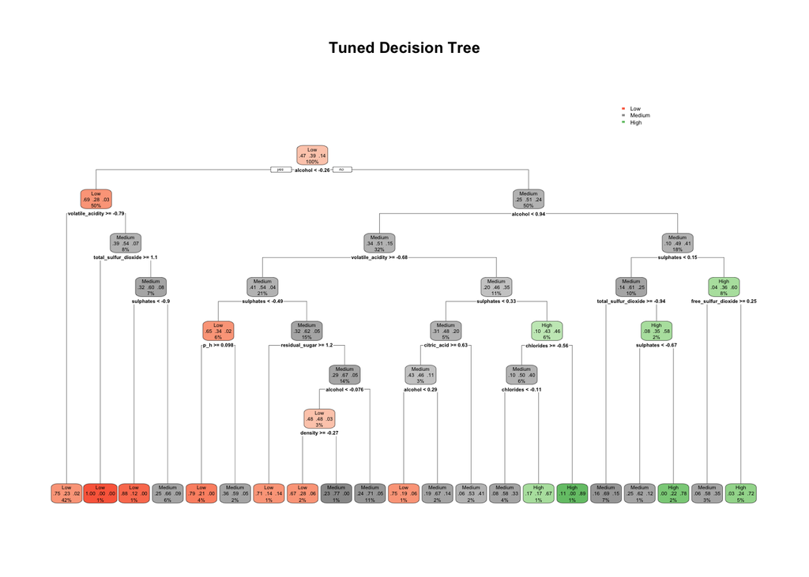

```r
rpart.plot(tree_tuned$finalModel, extra = 104, main = "Tuned Decision Tree")
```

```r
# Save a high-resolution version
png("decision_tree.png", width = 1600, height = 1000, res = 150)
rpart.plot(tree_tuned$finalModel, extra = 104, main = "Tuned Decision Tree")
dev.off()
```

```r
png("decision_tree.png", width = 1600, height = 1000, res = 150)
rpart.plot(tree_tuned$finalModel, extra = 104, main = "Tuned Decision Tree")
dev.off()
```

### Tuned Decision Tree

The decision tree plot below shows how the model splits the data based on wine attributes:

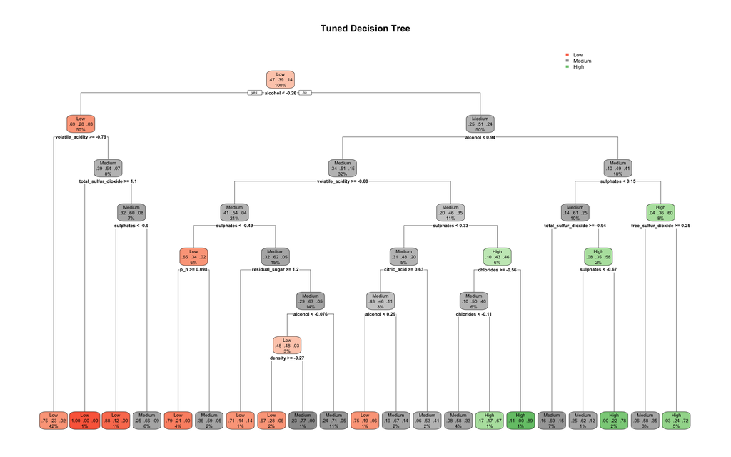

Tuned Decision Tree

random forest

```r
# Set up cross-validation
rf_control <- trainControl(method = "cv", number = 10)

# Optional: tuning grid for mtry (number of features to try at each split)
rf_grid <- expand.grid(mtry = c(2, 4, 6, 8))

# Train the model
set.seed(123)
rf_tuned <- train(
  quality_cat ~ . -quality,
  data = train_class,
  method = "rf",
  trControl = rf_control,
  tuneGrid = rf_grid,
  metric = "Accuracy"

)

print(rf_tuned)
```

```
## Random Forest
##
## 1088 samples
##   12 predictor
##    3 classes: 'Low', 'Medium', 'High'
##
## No pre-processing
## Resampling: Cross-Validated (10 fold)
## Summary of sample sizes: 978, 979, 979, 979, 979, 981, ...
## Resampling results across tuning parameters:
##
##   mtry  Accuracy   Kappa
##   2     0.6516384  0.4082466
##   4     0.6461676  0.4002395
##   6     0.6479430  0.4040090
##   8     0.6452677  0.4008597
##
## Accuracy was used to select the optimal model using the largest value.
## The final value used for the model was mtry = 2.
```

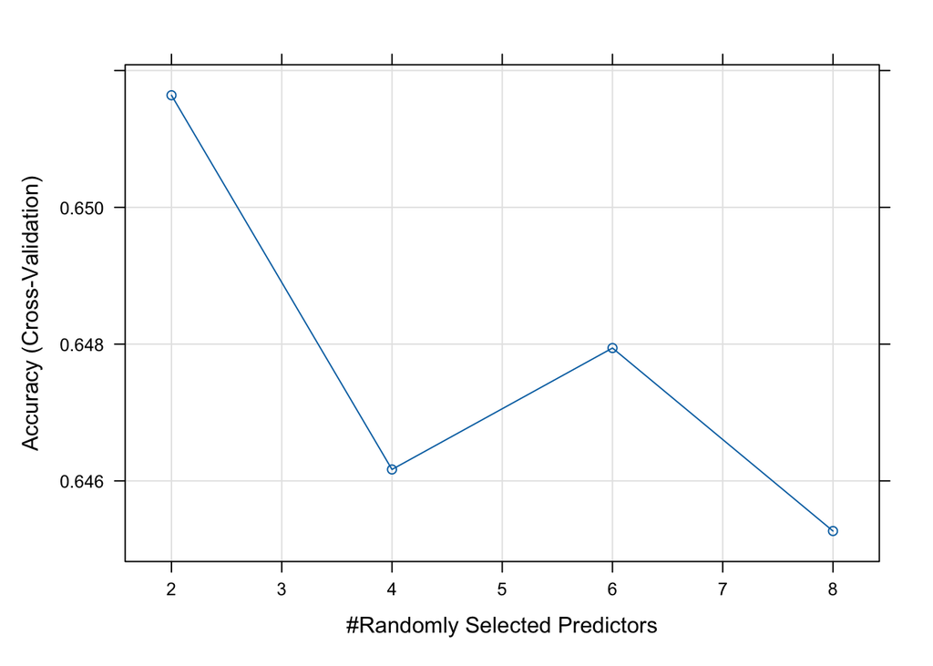

```r
plot(rf_tuned)
```

```r
 # Predict on test set
rf_pred <- predict(rf_tuned, newdata = test_class)

# Confusion matrix
confusionMatrix(rf_pred, test_class$quality_cat)
```

```
## Confusion Matrix and Statistics
##
##           Reference
## Prediction Low Medium High
##     Low    100     43    2
##     Medium  27     55   18
##     High     1      9   16
##
## Overall Statistics
##
##                Accuracy : 0.631
##                  95% CI : (0.5705, 0.6886)
##     No Information Rate : 0.4723
##     P-Value [Acc > NIR] : 1.087e-07
##
##                   Kappa : 0.3733
##
##  Mcnemar's Test P-Value : 0.0722
##
## Statistics by Class:
##
##                      Class: Low Class: Medium Class: High
## Sensitivity              0.7812        0.5140     0.44444
## Specificity              0.6853        0.7256     0.95745
## Pos Pred Value           0.6897        0.5500     0.61538
## Neg Pred Value           0.7778        0.6959     0.91837
## Prevalence               0.4723        0.3948     0.13284
## Detection Rate           0.3690        0.2030     0.05904
## Detection Prevalence     0.5351        0.3690     0.09594
## Balanced Accuracy        0.7333        0.6198     0.70095
```

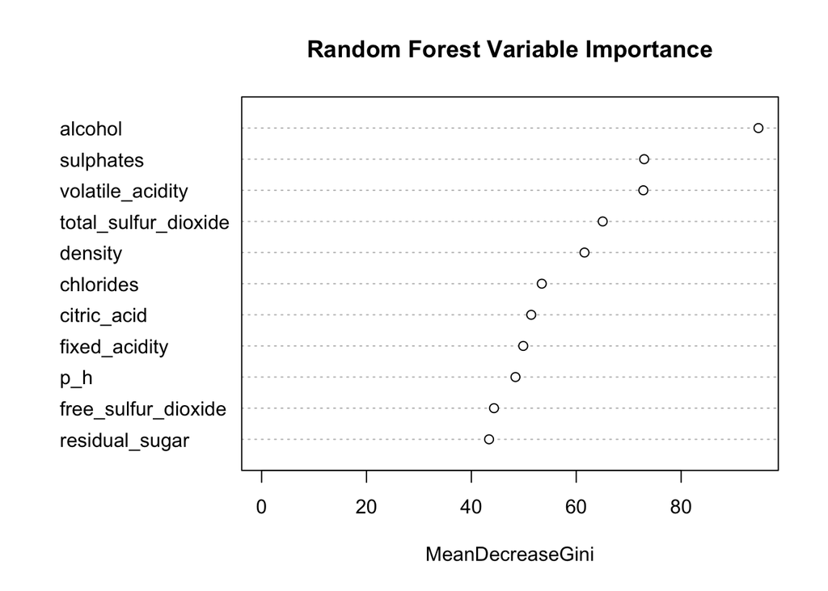

```r
# Plot variable importance
varImpPlot(rf_tuned$finalModel, main = "Random Forest Variable Importance")
```

#import csv file to R and prepare data

In this step, we will load the wine quality dataset, explore its basic structure, and prepare it for further analysis. This includes: - Importing the data - Checking its structure and summary - Identifying any missing values or duplicates - Scaling (standardizing) the numeric variables for modeling

To help us in our task of cleaning the data wer are using the tidyverse library

The dataset contains physicochemical attributes of red wine samples along with a sensory quality rating (from 0 to 10). The table below summarizes the distribution of each variable using key descriptive statistics: minimum, 1st quartile, median, mean, 3rd quartile, and maximum.

🔍 Key Observations: Fixed Acidity: Ranges from 4.6 to 15.9, with a mean of 8.32. Most values fall between 7.1 and 9.2.

Volatile Acidity: Skews low, ranging from 0.12 to 1.58. The median is 0.52, showing most samples are on the lower side, which is desirable for wine quality.

Residual Sugar: The range (0.9 to 15.5) shows high variability; the mean (2.54) is higher than the median (2.2), suggesting a right-skewed distribution due to outliers.

Free Sulfur Dioxide: Median of 14, but a max of 72, indicating some extreme values.

Total Sulfur Dioxide: Widely dispersed, ranging up to 289 with a median of 38. This could impact flavor and preservation.

Density: Very narrow range (0.9901 to 1.0037), as expected for liquids, with a mean of 0.9967.

pH: Ranges from 2.74 to 4.01, centered around a mean of 3.31 — typical acidity for red wine.

Sulphates: Ranges from 0.33 to 2.00; most values lie below 0.73, with a positively skewed distribution.

Alcohol: Varies from 8.4% to 14.9%. The mean (10.42%) suggests moderate alcohol content overall, with higher alcohol levels possibly improving wine quality.

while checking the data set for missing values turn out we had no missing values as they returned 0 for all column

We have found 240 duplicate acrross all rows which we have later delete to keep only the unique rows

Notably:

The presence of outliers in variables such as sulphates, fixed_acidity, and volatile_acidity should be assessed visually to determine whether they represent data quality issues or genuine extreme values.